# exercises3

### Definitions

We assume that there exists a continuous function $f(\boldsymbol{x})$ and a normal distributed error $\boldsymbol{\varepsilon}\sim N(0, \sigma^2)$ which describes our data

$$ A1: \quad \boldsymbol{y} = f(\boldsymbol{x})+\boldsymbol{\varepsilon} $$

We further assume that this continous function can be modeled with a linear model $\mathbf{\tilde{y}}$ of some features $\mathbf{X}$.

$$ A2: \quad \boldsymbol{y} = \boldsymbol{\tilde{y}} + \boldsymbol{\varepsilon} = \boldsymbol{X}\boldsymbol{\beta} +\boldsymbol{\varepsilon} $$

We therefore get that our data $\boldsymbol{y}$ has an expectation value $\boldsymbol{X}\boldsymbol{\beta}$ and variance $\sigma^2$, that is $\boldsymbol{y}$ follows a normal distribution with mean value $\boldsymbol{X}\boldsymbol{\beta}$ and variance $\sigma^2$.

## Exercise 1: Expectation values for ordinary least squares expressions

### **a)** With the expressions for the optimal parameters $\boldsymbol{\hat{\beta}_{OLS}}$ show that

## $$ \mathbb{E}(\boldsymbol{\hat{\beta}_{OLS}}) = \boldsymbol{\beta}. $$

We start with the definition of the OLS estimator

$$ \hat{\boldsymbol{\beta}}_{OLS} = (X^\top X)^{-1} X^\top \boldsymbol{y}. $$

From the data generating process we have

$$ \boldsymbol{y} = X \boldsymbol{\beta} + \boldsymbol{\epsilon}, \quad \boldsymbol{\epsilon} \sim \mathcal{N}(0, \sigma^2 I). $$

Insert this expression for $\boldsymbol{y}$ into the estimator (this step is using the assumption (A2) that the ideal $\beta$ is expressed from $X$ where only noise is stochastic)

$$ \hat{\boldsymbol{\beta}}_{OLS} = (X^\top X)^{-1} X^\top (X \boldsymbol{\beta} + \boldsymbol{\epsilon}). $$

Expand the product:

$$ \hat{\boldsymbol{\beta}}_{OLS} = (X^\top X)^{-1} X^\top X \boldsymbol{\beta} \;+\; (X^\top X)^{-1} X^\top \boldsymbol{\epsilon}. $$

Simplify:

$$ \hat{\boldsymbol{\beta}}_{OLS} = \boldsymbol{\beta} + (X^\top X)^{-1} X^\top \boldsymbol{\epsilon}. $$

Now take the expectation, using linearity of expectation and the fact that $\boldsymbol{\beta}$ is non-stochastic while $\mathbb{E}[\boldsymbol{\epsilon}] = 0$: $$ \mathbb{E}[\hat{\boldsymbol{\beta}}_{OLS}] = \mathbb{E}[\boldsymbol{\beta} + (X^\top X)^{-1} X^\top \boldsymbol{\epsilon}]. $$

Since $\boldsymbol{\beta}$ is non-stochastic and $\mathbb{E}[\boldsymbol{\epsilon}] = 0$:

$$ \mathbb{E}[\hat{\boldsymbol{\beta}}_{OLS}] = \boldsymbol{\beta} + (X^\top X)^{-1} X^\top \,\mathbb{E}[\boldsymbol{\epsilon}], $$

$$ \mathbb{E}[\hat{\boldsymbol{\beta}}_{OLS}] = \boldsymbol{\beta}. $$

Hence, the OLS estimator is **unbiased**:

$$ \mathbb{E}[\hat{\boldsymbol{\beta}}_{OLS}] = \boldsymbol{\beta}. $$

### **b)** Show that the variance of $\boldsymbol{\hat{\beta}_{OLS}}$ is

$$ \mathbf{Var}(\boldsymbol{\hat{\beta}_{OLS}}) = \sigma^2 \, (\mathbf{X}^{T} \mathbf{X})^{-1}. $$

We start from the expression for the OLS estimator obtained above:

$$ \hat{\boldsymbol{\beta}}_{OLS} = \boldsymbol{\beta} + (X^\top X)^{-1} X^\top \boldsymbol{\epsilon}. $$

The variance operator ignores constants, so only the second term contributes. Thus,

$$ \operatorname{Var}(\hat{\boldsymbol{\beta}}_{OLS}) = \operatorname{Var}\!\left( (X^\top X)^{-1} X^\top \boldsymbol{\epsilon} \right). $$

Factor out the non-random matrices:

$$ \operatorname{Var}(\hat{\boldsymbol{\beta}}_{OLS}) = (X^\top X)^{-1} X^\top \, \operatorname{Var}(\boldsymbol{\epsilon}) \, X (X^\top X)^{-1}. $$

From the data generating assumption we know

$$ \operatorname{Var}(\boldsymbol{\epsilon}) = \sigma^2 I. $$

Substitute this:

$$ \operatorname{Var}(\hat{\boldsymbol{\beta}}_{OLS}) = (X^\top X)^{-1} X^\top \, (\sigma^2 I) \, X (X^\top X)^{-1}. $$

Simplify:

$$ \operatorname{Var}(\hat{\boldsymbol{\beta}}_{OLS}) = \sigma^2 (X^\top X)^{-1} X^\top X (X^\top X)^{-1}. $$

Since $X^\top X$ is symmetric and invertible (under the Gauss-Markov assumptions, i.e no perfect multicollinearity / full column rank assumption, (Wikipedia contributors, 2025)). ):

$$ \operatorname{Var}(\hat{\boldsymbol{\beta}}_{OLS}) = \sigma^2 (X^\top X)^{-1}. $$

Hence, we have shown that:

$$ \operatorname{Var}(\hat{\boldsymbol{\beta}}_{OLS}) = \sigma^2 (X^\top X)^{-1}. $$

Reference:

Wikipedia contributors. (2025, March 24). Gauss–Markov theorem. In Wikipedia. Retrieved September 10, 2025, from https://en.wikipedia.org/w/index.php?title=Gauss%E2%80%93Markov_theorem&oldid=1282157188

## Exercise 2: Expectation values for Ridge regression

**a)** With the expressions for the optimal parameters $\boldsymbol{\hat{\beta}_{Ridge}}$ show that

$$ \mathbb{E} \big[ \hat{\boldsymbol{\beta}}^{\mathrm{Ridge}} \big]=(\mathbf{X}^{T} \mathbf{X} + \lambda \mathbf{I}_{pp})^{-1} (\mathbf{X}^{\top} \mathbf{X})\boldsymbol{\beta} $$

We start with the definition of the Ridge estimator:

$$ \hat{\boldsymbol{\beta}}_{Ridge} = (X^\top X + \lambda I_p)^{-1} X^\top \boldsymbol{y}, $$

where $\lambda > 0$ is the regularization parameter and $I_p$ is the $p \times p$ identity matrix.

From the data generating process we have

$$ \boldsymbol{y} = X \boldsymbol{\beta} + \boldsymbol{\epsilon}, \quad \boldsymbol{\epsilon} \sim \mathcal{N}(0, \sigma^2 I). $$

Insert this into the estimator:

$$ \hat{\boldsymbol{\beta}}_{Ridge} = (X^\top X + \lambda I_p)^{-1} X^\top (X \boldsymbol{\beta} + \boldsymbol{\epsilon}). $$

Expand:

$$ \hat{\boldsymbol{\beta}}_{Ridge} = (X^\top X + \lambda I_p)^{-1} X^\top X \boldsymbol{\beta} \;+\; (X^\top X + \lambda I_p)^{-1} X^\top \boldsymbol{\epsilon}. $$

Now take the expectation, using linearity and $\mathbb{E}[\boldsymbol{\epsilon}] = 0$ so that last term zeros:

$$ \mathbb{E}[\hat{\boldsymbol{\beta}}_{Ridge}] = (X^\top X + \lambda I_p)^{-1} X^\top X \boldsymbol{\beta}. $$

Thus we have shown:

$$ \mathbb{E}[\hat{\boldsymbol{\beta}}_{Ridge}] = (X^\top X + \lambda I_p)^{-1} (X^\top X) \boldsymbol{\beta}. $$

Note:

Therefore by inspection of the expression we see $$ \mathbb{E}[\hat{\boldsymbol{\beta}}_{Ridge}] = \mathbb{E}[\hat{\boldsymbol{\beta}}_{OLS}] \iff \lambda = 0 $$ Hence for any $\lambda > 0$ the Ridge estimator is biased.

**b)** Why do we say that Ridge regression gives a biased estimate? Is this a problem?

According to the bias–variance tradeoff (Hastie, Tibshirani, and Friedman, 2009, p.223), introducing bias can be beneficial.  
Ridge adds bias by shrinking the estimator coefficients, but in turn it reduces variance, notably when predictors are highly correlated and the feature matrix $X$ is close to singular.

Its strength lies under conditions of multicollinearity or high dimensionality, where it effectively trades some bias for lower variance.  
In practical settings, this is valuable: measurement noise, limited sample sizes, or strongly correlated features can make the OLS estimator oversensitive and unstable. Ridge stabilizes the solution, lowering mean squared error even though it is biased.

Reference:

Trevor Hastie, Robert Tibshirani, and Jerome Friedman. The Elements of Statistical Learning: Data Mining, Inference, and Prediction}. Second Edition. Springer, 2009.

**c)** Show that the variance is

$$ \mathbf{Var}[\hat{\boldsymbol{\beta}}^{\mathrm{Ridge}}]=\sigma^2[ \mathbf{X}^{T} \mathbf{X} + \lambda \mathbf{I} ]^{-1} \mathbf{X}^{T}\mathbf{X} \{ [ \mathbf{X}^{\top} \mathbf{X} + \lambda \mathbf{I} ]^{-1}\}^{T} $$

We see that if the parameter $\lambda$ goes to infinity then the variance of the Ridge parameters $\boldsymbol{\beta}$ goes to zero.

The proof in structure is similar to the others. We start from the expression of the Ridge estimator:

$$ \hat{\boldsymbol{\beta}}_{Ridge} = (X^\top X + \lambda I_p)^{-1} X^\top \boldsymbol{y}. $$

From the data generating process we have

$$ \boldsymbol{y} = X \boldsymbol{\beta} + \boldsymbol{\epsilon}, \quad \boldsymbol{\epsilon} \sim \mathcal{N}(0, \sigma^2 I). $$

Insert this into the estimator:

$$ \hat{\boldsymbol{\beta}}_{Ridge} = (X^\top X + \lambda I_p)^{-1} X^\top (X \boldsymbol{\beta} + \boldsymbol{\epsilon}). $$

Expand:

$$ \hat{\boldsymbol{\beta}}_{Ridge} = (X^\top X + \lambda I_p)^{-1} X^\top X \boldsymbol{\beta} \;+\; (X^\top X + \lambda I_p)^{-1} X^\top \boldsymbol{\epsilon}. $$

The first term is deterministic by assumption, hence only the second contributes to the variance:

$$ \operatorname{Var}(\hat{\boldsymbol{\beta}}_{Ridge}) = \operatorname{Var}\!\left( (X^\top X + \lambda I_p)^{-1} X^\top \boldsymbol{\epsilon} \right). $$

Using the variance matrix rule for independent "errors" $\operatorname{Var}(A\boldsymbol{\epsilon}) = A \, \operatorname{Var}(\boldsymbol{\epsilon}) \, A^\top$:

$$ \operatorname{Var}(\hat{\boldsymbol{\beta}}_{Ridge}) = (X^\top X + \lambda I_p)^{-1} X^\top \, \operatorname{Var}(\boldsymbol{\epsilon}) \, X \big[(X^\top X + \lambda I_p)^{-1}\big]^\top. $$

Since $\operatorname{Var}(\boldsymbol{\epsilon}) = \sigma^2 I$:

$$ \operatorname{Var}(\hat{\boldsymbol{\beta}}_{Ridge}) = \sigma^2 (X^\top X + \lambda I_p)^{-1} X^\top X \big[(X^\top X + \lambda I_p)^{-1}\big]^\top. $$

Note:

We can now see that as $\lambda \to \infty$, the shrinkage term $(X^\top X + \lambda I_p)^{-1}$ goes to zero, so

$$ \lim_{\lambda \to \infty} \operatorname{Var}(\hat{\boldsymbol{\beta}}_{Ridge}) = 0. $$

Such a dynamic clearly invokes the general bias-variance tradeoff, as $\lambda$ increases so does bias, concurrently the estimator variance shrinks

## Exercise 3: Deriving the expression for the Bias-Variance Trade-off

The aim of this exercise is to derive the equations for the bias-variance tradeoff to be used in project 1.

The parameters $\boldsymbol{\hat{\beta}_{OLS}}$ are found by optimizing the mean squared error via the so-called cost function

$$ C(\boldsymbol{X},\boldsymbol{\beta}) =\frac{1}{n}\sum_{i=0}^{n-1}(y_i-\tilde{y}_i)^2=\mathbb{E}\left[(\boldsymbol{y}-\boldsymbol{\tilde{y}})^2\right] $$

**a)** Show that you can rewrite this into an expression which contains

- the variance of the model (the variance term)
- the expected deviation of the mean of the model from the true data (the bias term)
- the variance of the noise

In other words, show that:

$$ \mathbb{E}\left[(\boldsymbol{y}-\boldsymbol{\tilde{y}})^2\right]=\mathrm{Bias}[\tilde{y}]+\mathrm{var}[\tilde{y}]+\sigma^2, $$

with

$$ \mathrm{Bias}[\tilde{y}]=\mathbb{E}\left[\left(\boldsymbol{y}-\mathbb{E}\left[\boldsymbol{\tilde{y}}\right]\right)^2\right], $$

and

$$ \mathrm{var}[\tilde{y}]=\mathbb{E}\left[\left(\tilde{\boldsymbol{y}}-\mathbb{E}\left[\boldsymbol{\tilde{y}}\right]\right)^2\right]=\frac{1}{n}\sum_i(\tilde{y}_i-\mathbb{E}\left[\boldsymbol{\tilde{y}}\right])^2. $$

We want to decompose the mean squared error

$$ \mathbb{E}[(y - \hat{y})^2]. $$

Start with the data generating process:

$$ y = f(x) + \epsilon, \quad \epsilon \sim \mathcal{N}(0, \sigma^2). $$

So,

$$ \mathbb{E}[(y - \hat{y})^2] = \mathbb{E}[(f(x) + \epsilon - \hat{y})^2]. $$

Expand:

$$ \mathbb{E}[(f(x) - \hat{y} + \epsilon)^2] = \mathbb{E}[(f(x) - \hat{y})^2] + 2\mathbb{E}[(f(x) - \hat{y})\epsilon] + \mathbb{E}[\epsilon^2]. $$

Since $\epsilon$ is independent with zero mean, the cross-term vanishes:

$$ \mathbb{E}[(y - \hat{y})^2] = \mathbb{E}[(f(x) - \hat{y})^2] + \sigma^2. $$

Now decompose the first term by adding and subtracting $\mathbb{E}[\hat{y}]$ ((Hastie, Tibshirani, and Friedman, 2009, p.223)):

$$ \mathbb{E}[(f(x) - \hat{y})^2] = \mathbb{E}\big[(f(x) - \mathbb{E}[\hat{y}] + \mathbb{E}[\hat{y}] - \hat{y})^2\big]. $$

Expand:

$$ = \mathbb{E}\big[(f(x) - \mathbb{E}[\hat{y}])^2\big] + \mathbb{E}\big[(\hat{y} - \mathbb{E}[\hat{y}])^2\big] + 2\mathbb{E}\big[(f(x) - \mathbb{E}[\hat{y}])(\mathbb{E}[\hat{y}] - \hat{y})\big]. $$

The cross-term vanishes because $(f(x) - \mathbb{E}[\hat{y}])$ is constant w.r.t. the randomness in $\hat{y}$. So:

$$ \mathbb{E}[(f(x) - \hat{y})^2] = (f(x) - \mathbb{E}[\hat{y}])^2 + \operatorname{Var}(\hat{y}). $$

Thus the full decomposition is

$$ \mathbb{E}[(y - \hat{y})^2] = (f(x) - \mathbb{E}[\hat{y}])^2 + \operatorname{Var}(\hat{y}) + \sigma^2. $$

Identify terms:

- Bias: $\operatorname{Bias}[\hat{y}]^2 = (f(x) - \mathbb{E}[\hat{y}])^2$
- Variance: $\operatorname{Var}[\hat{y}] = \mathbb{E}[(\hat{y} - \mathbb{E}[\hat{y}])^2]$
- Nondeterministic noise: $\sigma^2$

So:

$$ \mathbb{E}[(y - \hat{y})^2] = \operatorname{Bias}[\hat{y}]^2 + \operatorname{Var}[\hat{y}] + \sigma^2. $$

**b)** Explain what the terms mean and discuss their interpretations.

The decomposition above splits predictive error into three conceptual parts.

- The irreducibile error comes from the fact of sampling, no matter how we well we estimate $f(x)$ noise is assumed and this variance cannot be reduce unless $\epsilon$ is assumed $\sim \sigma^2 = 0$
- Bias can be understood as systematic error, or the squared distance between the prediction expectation and the "true function" (underlying data-generating mechanism). Importantly, if the model class (e.g linear model) cannot represent the true function (e.g nonlinear function), bias is high. The more flexible the model is, the more it can reduce bias.

Forexample, for basis expansions (polynomials, splines), the model bias can be made arbitrarily small by letting the number of basis functions $p$ grow, since such bases are dense in the space of continuous functions (Hastie et al., 2009, 233).

- Variance: sensitivity of the estimator to sampling fluctuations. It measures how much $\hat{y}$ (determined by the estimator and noise) varies around its mean $\mathbb{E}[\hat{y}]$ when the training data changes. High variance means the model is more "sensitive" / (over)fits to noise in the training set.

Hence, in most cases, the total mean squared error is the main metric for model assessment. This is an overarching metric combining the tradeoffs central for model assessment

## Exercise 4: Computing the Bias and Variance

Before you compute the bias and variance of a real model for different complexities, let's for now assume that you have sampled predictions and targets for a single model complexity using bootstrap resampling.

**a)** Using the expression above, compute the mean squared error, bias and variance of the given data. Check that the sum of the bias and variance correctly gives (approximately) the mean squared error.

```python
import numpy as np

n = 100
bootstraps = 1000

predictions = np.random.rand(bootstraps, n) * 10 + 10
targets = np.random.rand(bootstraps, n)

# lets simply assume that the truth for comparison is the mean vector of the target
true_values = np.mean(targets, axis=0)

# get MSE
mse = np.mean((targets - predictions)**2)

expected_predictions = np.mean(predictions, axis=0)
bias_squared = np.mean((expected_predictions - true_values)**2)

variance = np.mean((predictions - expected_predictions)**2)

print(f"MSE: {mse:.4f}")
print(f"Bias**2: {bias_squared:.4f}")
print(f"Variance: {variance:.4f}")
print(f"Bias **2 + Variance: {bias_squared + variance:.4f}")
print(f"Difference (should be approx noise variance): {mse - (bias_squared + variance):.4f}")
```

```
MSE: 218.8889
Bias**2: 210.4532
Variance: 8.3585
Bias **2 + Variance: 218.8117
Difference (should be approx noise variance): 0.0771
```

**b)** Change the prediction values in some way to increase the bias while decreasing the variance.

```python
#the old predictions were 10 units wide, these are now 2 wide (less spread), and we shift + 20 to induce systematic offset (bias)
predictions_high_bias = np.random.rand(bootstraps, n) * 2 + 20  # Less spread, shifted away from targets

#compare with old
true_values = np.mean(targets, axis=0)

#original calculations
mse_orig = np.mean((targets - predictions)**2)
expected_predictions_orig = np.mean(predictions, axis=0)
bias_squared_orig = np.mean((expected_predictions_orig - true_values)**2)
variance_orig = np.mean((predictions - expected_predictions_orig)**2)

#compare w higher bias less spread dataset
mse_high_bias = np.mean((targets - predictions_high_bias)**2)
expected_predictions_high_bias = np.mean(predictions_high_bias, axis=0)
bias_squared_high_bias = np.mean((expected_predictions_high_bias - true_values)**2)
variance_high_bias = np.mean((predictions_high_bias - expected_predictions_high_bias)**2)

print("Original predictions:")
print(f"  MSE: {mse_orig:.4f}, Bias**2: {bias_squared_orig:.4f}, Variance: {variance_orig:.4f}")
print("\nHigh bias predictions:")
print(f"  MSE: {mse_high_bias:.4f}, Bias**2: {bias_squared_high_bias:.4f}, Variance: {variance_high_bias:.4f}")
print(f"\n Bias**2 delta: {bias_squared_high_bias - bias_squared_orig:.4f}")
print(f"Variance delta: {variance_high_bias - variance_orig:.4f}")
print("\nAs expected, increasing bias shrinks variance, showing the bias–variance tradeoff.")
```

```
Original predictions:
  MSE: 218.8889, Bias**2: 210.4532, Variance: 8.3585

High bias predictions:
  MSE: 420.7116, Bias**2: 420.2958, Variance: 0.3332

 Bias**2 delta: 209.8425
Variance delta: -8.0253

As expected, increasing bias shrinks variance, showing the bias–variance tradeoff.
```

**c)** Change the prediction values in some way to increase the variance while decreasing the bias.

```python
# the old predictions were 10 units wide, these are now 20 wide (more spread),
# but centered around the targets to keep bias smaller
predictions_high_var = np.random.rand(bootstraps, n) * 20 + (true_values.mean() - 10)

# compare with old
mse_high_var = np.mean((targets - predictions_high_var)**2)
expected_predictions_high_var = np.mean(predictions_high_var, axis=0)
bias_squared_high_var = np.mean((expected_predictions_high_var - true_values)**2)
variance_high_var = np.mean((predictions_high_var - expected_predictions_high_var)**2)

print("Original predictions:")
print(f"  MSE: {mse_orig:.4f}, Bias**2: {bias_squared_orig:.4f}, Variance: {variance_orig:.4f}")
print("\nHigh variance predictions:")
print(f"  MSE: {mse_high_var:.4f}, Bias**2: {bias_squared_high_var:.4f}, Variance: {variance_high_var:.4f}")
print(f"\n Bias**2 delta: {bias_squared_high_var - bias_squared_orig:.4f}")
print(f"Variance delta: {variance_high_var - variance_orig:.4f}")
```

```
Original predictions:
  MSE: 218.8889, Bias**2: 210.4532, Variance: 8.3585

High variance predictions:
  MSE: 33.3732, Bias**2: 0.0341, Variance: 33.2608

 Bias**2 delta: -210.4191
Variance delta: 24.9023
```

**d)** Perform a bias-variance analysis of a polynomial OLS model fit to a one-dimensional function by computing and plotting the bias and variances values as a function of the polynomial degree of your model.

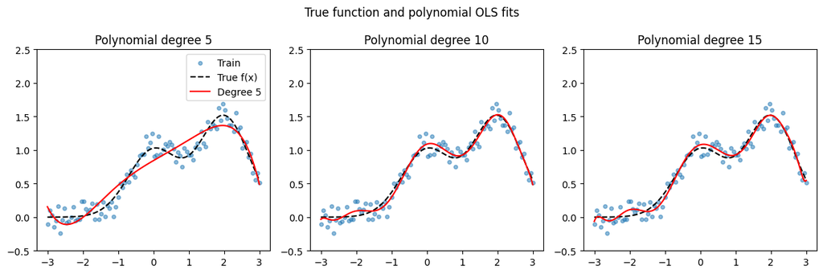

```python
import numpy as np
import matplotlib.pyplot as plt
from sklearn.preprocessing import PolynomialFeatures
from sklearn.linear_model import LinearRegression

np.random.seed(123)

def f(x):
    return np.exp(-(x**2)) + 1.5 * np.exp(-((x - 2) ** 2))

n = 100
x = np.linspace(-3, 3, n)
y = f(x) + np.random.normal(0, 0.1, n)

degrees = [5, 10, 15]
x_plot = np.linspace(-3, 3, 400).reshape(-1, 1)
y_true = f(x_plot.ravel())

plt.figure(figsize=(12, 4))

for i, d in enumerate(degrees, 1):
    poly = PolynomialFeatures(d)
    X = poly.fit_transform(x.reshape(-1, 1))
    X_plot = poly.transform(x_plot)

    model = LinearRegression()
    model.fit(X, y)
    y_pred = model.predict(X_plot)

    plt.subplot(1, 3, i)
    plt.scatter(x, y, s=15, alpha=0.5, label="Train")
    plt.plot(x_plot, y_true, "k--", label="True f(x)")
    plt.plot(x_plot, y_pred, "r", label=f"Degree {d}")
    plt.title(f"Polynomial degree {d}")
    plt.ylim(-0.5, 2.5)
    if i == 1:
        plt.legend()

plt.suptitle("True function and polynomial OLS fits")
plt.tight_layout()
plt.show()
```

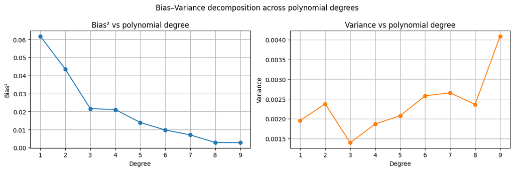

```python
from sklearn.utils import resample

bootstraps = 200

def plot_bias_variance(degrees: range, semilog: bool):
    biases, variances = [], []

    x_plot = np.linspace(-3, 3, 200).reshape(-1, 1)
    y_true = f(x_plot.ravel())

    for d in degrees:
        predictions = np.zeros((bootstraps, len(x_plot)))

        poly = PolynomialFeatures(d)
        X_plot = poly.fit_transform(x_plot)

        for b in range(bootstraps):
            x_res, y_res = resample(x, y)
            X_res = poly.transform(x_res.reshape(-1, 1))
            model = LinearRegression()
            model.fit(X_res, y_res)
            predictions[b, :] = model.predict(X_plot)

        mean_pred = predictions.mean(axis=0)
        bias2 = np.mean((mean_pred - y_true) ** 2)
        var = np.mean(np.var(predictions, axis=0))

        biases.append(bias2)
        variances.append(var)

    # Plot
    fig, axes = plt.subplots(1, 2, figsize=(12, 4))

    axes[0].plot(degrees, biases, 'o-', color='tab:blue')
    axes[0].set_title("Bias² vs polynomial degree")
    axes[0].set_xlabel("Degree")
    axes[0].set_ylabel("Bias²")
    axes[0].grid(True)

    axes[1].plot(degrees, variances, 'o-', color='tab:orange')
    axes[1].set_title("Variance vs polynomial degree")
    axes[1].set_xlabel("Degree")
    axes[1].set_ylabel("Variance")
    axes[1].grid(True)

    if semilog:
        axes[0].set_yscale("log")
        axes[1].set_yscale("log")

    plt.suptitle("Bias–Variance decomposition across polynomial degrees")
    plt.tight_layout()
    plt.show()


plot_bias_variance(range(1, 10), semilog=False)
```

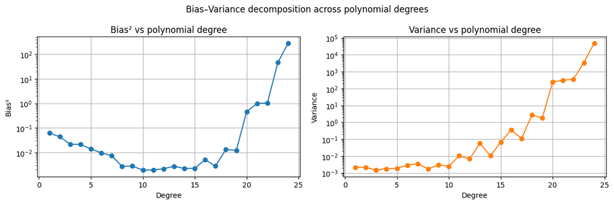

```python
plot_bias_variance(range(1,25), semilog = True)
```

**e)** Discuss the bias-variance trade-off as function of your model complexity (the degree of the polynomial).

**f)** Compute and discuss the bias and variance as function of the number of data points (choose a suitable polynomial degree to show something interesting).

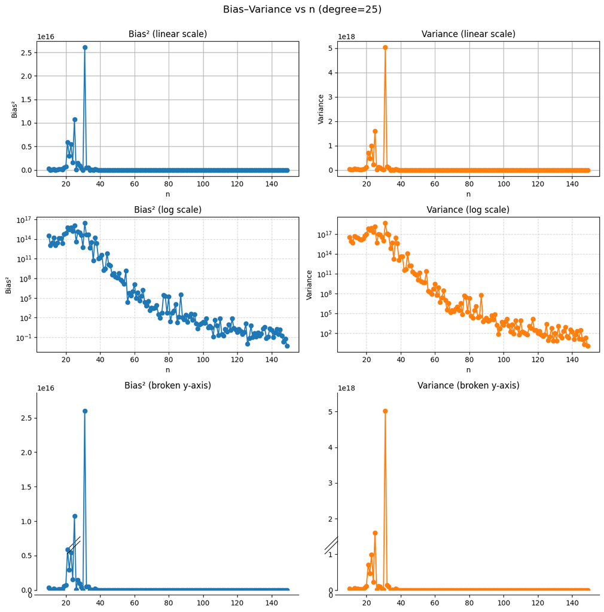

```python
import numpy as np
import matplotlib.pyplot as plt
from sklearn.preprocessing import PolynomialFeatures
from sklearn.linear_model import LinearRegression
from sklearn.utils import resample
from brokenaxes import brokenaxes   # pip install brokenaxes

degree_fixed = 25
bootstraps = 200
n_list = np.arange(10, 150, 1)

biases_n, variances_n = [], []

x_plot = np.linspace(-3, 3, 200).reshape(-1, 1)
y_true = f(x_plot.ravel())
poly = PolynomialFeatures(degree_fixed)
X_plot = poly.fit_transform(x_plot)

for n in n_list:
    x_sample = np.linspace(-3, 3, n)
    y_sample = f(x_sample) + np.random.normal(0, 0.1, n)

    predictions = np.zeros((bootstraps, len(x_plot)))
    for b in range(bootstraps):
        x_res, y_res = resample(x_sample, y_sample)
        X_res = poly.transform(x_res.reshape(-1, 1))
        model = LinearRegression()
        model.fit(X_res, y_res)
        predictions[b, :] = model.predict(X_plot)

    mean_pred = predictions.mean(axis=0)
    bias2 = np.mean((mean_pred - y_true) ** 2)
    var = np.mean(np.var(predictions, axis=0))

    biases_n.append(bias2)
    variances_n.append(var)

# --- Create 3x2 grid ---
fig = plt.figure(figsize=(12, 12))
gs = fig.add_gridspec(3, 2, height_ratios=[1, 1, 1.5])

# --- Linear scale ---
ax1 = fig.add_subplot(gs[0, 0])
ax1.plot(n_list, biases_n, 'o-', color='tab:blue')
ax1.set_title("Bias² (linear scale)")
ax1.set_xlabel("n")
ax1.set_ylabel("Bias²")
ax1.grid(True)

ax2 = fig.add_subplot(gs[0, 1])
ax2.plot(n_list, variances_n, 'o-', color='tab:orange')
ax2.set_title("Variance (linear scale)")
ax2.set_xlabel("n")
ax2.set_ylabel("Variance")
ax2.grid(True)

# --- Log scale ---
ax3 = fig.add_subplot(gs[1, 0])
ax3.plot(n_list, biases_n, 'o-', color='tab:blue')
ax3.set_title("Bias² (log scale)")
ax3.set_xlabel("n")
ax3.set_ylabel("Bias²")
ax3.set_yscale("log")
ax3.grid(True, which="both", ls="--", alpha=0.5)

ax4 = fig.add_subplot(gs[1, 1])
ax4.plot(n_list, variances_n, 'o-', color='tab:orange')
ax4.set_title("Variance (log scale)")
ax4.set_xlabel("n")
ax4.set_ylabel("Variance")
ax4.set_yscale("log")
ax4.grid(True, which="both", ls="--", alpha=0.5)

# --- Broken y-axes ---
bax_bias = brokenaxes(
    ylims=((0, 2.0), (1e6, max(biases_n) * 1.1)),
    hspace=0.05,
    subplot_spec=gs[2, 0],
)
bax_bias.plot(n_list, biases_n, 'o-', color='tab:blue')
bax_bias.set_title("Bias² (broken y-axis)")

bax_var = brokenaxes(
    ylims=((0, 2.0), (1e6, max(variances_n) * 1.1)),
    hspace=0.05,
    subplot_spec=gs[2, 1],
)
bax_var.plot(n_list, variances_n, 'o-', color='tab:orange')
bax_var.set_title("Variance (broken y-axis)")

plt.suptitle(f"Bias–Variance vs n (degree={degree_fixed})", y=1, fontsize=14)
plt.tight_layout()
plt.show()
```

```python
import pandas as pd

df = pd.DataFrame({
    "n": n_list,
    "Bias²": biases_n,
    "Variance": variances_n
})

top_bias = df.sort_values("Bias²", ascending=False).head(10)
top_var = df.sort_values("Variance", ascending=False).head(10)

print("\nTop 10 n with highest Bias²:")
print(top_bias.to_string(index=False))

print("\nTop 10 n with highest Variance:")
print(top_var.to_string(index=False))
```

[output not shown]

### Discussion

For a polynomial regression of degree (d), the design matrix has the form of a Vandermonde

$$ X = \begin{bmatrix} 1 & x_1 & x_1^2 & \cdots & x_1^d \\ 1 & x_2 & x_2^2 & \cdots & x_2^d \\ \vdots & \vdots & \vdots & \ddots & \vdots \\ 1 & x_n & x_n^2 & \cdots & x_n^d \end{bmatrix} $$

Now, in our log plot, we see that the distribution looks alot like a log normal. Bias and variance increases exponentially and peaks at points where $n <\simeq 30$. As we know, in this domain our design matrix is fat. I.e

$$ X = \begin{bmatrix} 1 & x_1 & x_1^2 & x_1^3 & x_1^4 & x_1^5 & x_1^6 & x_1^7 \\ 1 & x_2 & x_2^2 & x_2^3 & x_2^4 & x_2^5 & x_2^6 & x_2^7 \\ 1 & x_3 & x_3^2 & x_3^3 & x_3^4 & x_3^5 & x_3^6 & x_3^7 \\ 1 & x_4 & x_4^2 & x_4^3 & x_4^4 & x_4^5 & x_4^6 & x_4^7 \end{bmatrix}_{4 \times 8} $$

The solution space is in general:

$$ \text{dim(ker(X))} = (d+1) - \text{rank}(X) \quad = \quad (d+1) - n $$

For the cases where n successes p, we have a **tall** matrix

## Interpretation

In the underdetermined case (n < p), the package sklearn uses the SVD solution to the OLS problem [1] The OLS solution is written as

$$ \hat\beta = X^+ y, $$

where $X^+$ is the Moore–Penrose pseudoinverse [2]. With SVD,

$$ X = U \Sigma V^\top, \quad X^+ = V \Sigma^+ U^\top, $$

where $\Sigma^+$ inverts only the nonzero singular values. This guarantees a consistent solution but does not control for ill-conditioning. The degree of ill-conditioning is measured by the condition number of $X$:

$$ \kappa(X) = \frac{\sigma_{\max}(X)}{\sigma_{\min}(X)}, $$

where $\sigma_{\max}, \sigma_{\min}$ are the largest and smallest nonzero singular values of $X$.

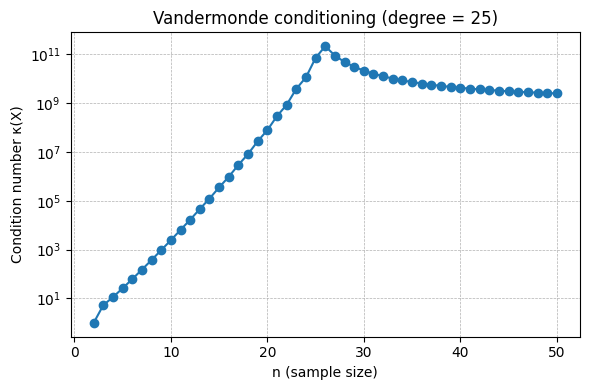

```python
from numpy.linalg import svd

def vandermonde_condition(x, degree):
    X = np.vander(x, degree+1, increasing=True)
    s = svd(X, compute_uv=False)
    return s.max() / s.min()

max_n = 50
degree = 25

n_list = np.arange(2, max_n+1)
cond_nums = []
for n in n_list:
    x = np.linspace(-1, 1, n)
    cond_nums.append(vandermonde_condition(x, degree))
cond_nums = np.array(cond_nums)

# Plot
plt.figure(figsize=(6,4))
plt.semilogy(n_list, cond_nums, marker="o")
plt.xlabel("n (sample size)")
plt.ylabel("Condition number κ(X)")
plt.title(f"Vandermonde conditioning (degree = {degree})")
plt.grid(True, which="both", linestyle="--", linewidth=0.5)
plt.tight_layout()
plt.show()
```

As we see, the conditioning grows exponentionally and peaks at $n \sim 25$, and then decays only slowly. Even when the system is overdetermined, the matrix remains highly ill-conditioned, and drops off as we would expected from a log normal.

In general we might say that for vandermonde matrices, for every degree we increase, the ill conditioning number will grow as a function of n and d. This is because $\sigma_{\max}(X)$ grows with both $n$ and $d$: each additional column adds powers of $x_i$, and for $x_i \in [-1,1]$ the column norms increase roughly like $\sqrt{n}$, so the largest singular value grows at least on the order of $\sqrt{n(d+1)}$.

Similarly, $\sigma_{\min}(X)$ shrinks as $d$ increases. Higher–degree columns become nearly collinear with earlier columns (e.g. $x^d$ is almost a scalar multiple of $x^{d-1}$ near $\pm 1$), so the span collapses. This drives the smallest singular value toward 0 as a function of both $n$ and $d$.

This relates to the bias-variance decomposition:

$$ \mathbb{E}\!\left[(\hat f(x)-f(x))^2\right] = \underbrace{(\mathbb{E}[\hat f(x)] - f(x))^2}_{\text{Bias}^2} + \underbrace{\mathbb{E}\!\big[(\hat f(x) - \mathbb{E}[\hat f(x)])^2\big]}_{\text{Variance}} + \sigma^2. $$

As the variance of $\hat{\beta}$ can be expressed through

$$ \mathrm{Var}(\hat{\beta}) = \sigma^2 (X^\top X)^{-1}, $$ Using the SVD, we see have $$ X^\top X = V \Sigma^2 V^\top, \qquad (X^\top X)^{-1} = V \Sigma^{-2} V^\top. $$ Hence $$ \mathrm{Var}(\hat{\beta}) = \sigma^2 V \Sigma^{-2} V^\top $$ As the matrix $\Sigma^{-2}$ has diagonal entries $\sigma_i^{-2}$, we see that the variance of $\hat{\beta}$ is dominated by the smallest singular values of $X$. When $\sigma_{\min}(X)$ is close to zero, the corresponding term $\sigma_{\min}^{-2}$ becomes very large, amplifying noise by a factor proportional to the conditioning ratio $ \frac{\sigma_{\max}(X)}{\sigma_{\min}(X)}$.

Sources: [1] Pedregosa, F., Varoquaux, G., Gramfort, A., Michel, V., Thirion, B., Grisel, O., Blondel, M., Prettenhofer, P., Weiss, R., Dubourg, V., Vanderplas, J., Passos, A., Cournapeau, D., Brucher, M., Perrot, M., & Duchesnay, E. (2011). Scikit-learn: Machine Learning in Python. Journal of Machine Learning Research, 12, 2825–2830. (Retrieved from: https://scikit-learn.org/stable/about.html) [2] Axler, S. (2025). Linear Algebra Done Right (4th ed.). Cham: Springer. https://doi.org/10.1007/978-3-031-56884-7

## Exercise 5: Interpretation of scaling and metrics

In this course, we often ask you to scale data and compute various metrics. Although these practices are "standard" in the field, we will require you to demonstrate an understanding of *why* you need to scale data and use these metrics. Both so that you can make better arguements about your results, and so that you will hopefully make fewer mistakes.

First, a few reminders: In this course you should always scale the columns of the feature matrix, and sometimes scale the target data, when it is worth the effort. By scaling, we mean subtracting the mean and dividing by the standard deviation, though there are many other ways to scale data. When scaling either the feature matrix or the target data, the intercept becomes a bit harder to implement and understand, so take care.

Briefly answer the following:

**a)** Why do we scale data?

Scaling ensures that the features are on comparable scale, avoiding dominance by large-magnitude variables. It stabilizes numerical computations, i.e when features differ by orders of magnitutde, small floating-point roundoff errors in large-scaled variables overshadow smaller-scaled variables. It also improves the condition of the design matrix $X^\top X$, i.e. it reduces eigenvalue spread; without scaling, large-magnitude features force eigenvalues to scale their eigenvectors along those directions, which makes inversion of $X^\top X$ sensitive because small perturbations in the data propagate strongly along ill-scaled directions

**b)** Why does the OLS method give practically equivelent models on scaled and unscaled data?

Because the OLS solution $\hat\beta = (X^\top X)^{-1}X^\top y$ is invariant up to linear rescaling of features (by linearity of matrix algebra), i.e multiplying a column of $X$ by a constant $c$ multiplies the corresponding coefficient by $1/c$. The predictions $\hat y = X\hat\beta$ remain unchanged, hence practically equivalent. The only effect is that the scale of coefficients depends on feature scaling, which complicates direct comparison of $\beta$-values across features.

**c)** Why does the Ridge method **not** give practically equivelent models on scaled and unscaled data? Why do we only consider the model on scaled data correct?

The ridge estimator is

$\hat\beta^{ridge} = (X^\top X + \lambda I)^{-1} X^\top y$.

The penalty term $\lambda \|\beta\|_2^2$ is applied uniformly across coefficients. So if features are on different scales, a coefficient corresponding to a large-scale feature appears large even when its contribution to predictions is modest, and the penalty distorts relative shrinkage. Thus scaling of $X$ directly affects the bias introduced by ridge, unlike in OLS.  
Only on scaled data does the penalty treat all features equivalently, making the ridge solution interpretable and the tradeoff between bias and variance meaningful.

**d)** Why do we say that the Ridge method gives a biased model?

Because ridge modifies the OLS estimator by adding $\lambda I$ to $X^\top X$, the solution

$ \hat\beta^{ridge} = (X^\top X + \lambda I)^{-1} X^\top y $

is systematically shifted toward zero. As stated above, this regularization shrinks coefficients even when the true $\beta$ is nonzero, introducing bias. The tradeoff is that variance is reduced, so the overall mean squared error often improves despite the estimator being biased.

**e)** Is the MSE of the OLS method affected by scaling of the feature matrix? Is it affected by scaling of the target data?

Scaling the feature matrix does not affect the MSE, because OLS predictions $\hat y = X\hat\beta$ are invariant to linear rescaling of $X$. The coefficients rescale inversely, leaving residuals and thus MSE unchanged.  
Scaling the target data does affect the MSE, since residuals are measured in the same units as $y$. Multiplying $y$ by a constant $c$ scales both residuals and MSE by $c^2$.

**f)** Read about the R2 score, a metric we will ask you to use a lot later in the course. Is the R2 score of the OLS method affected by scaling of the feature matrix? Is it affected by scaling of the target data?

Scaling the feature matrix does not affect the R2 score, since OLS predictions are invariant to rescaling of $X$.  
Scaling the target data also does not affect the 2 ² score, because both residual sum of squares (RSS) and total sum of squares (TSS) scale by the same factor $c^2$, so their ratio — and thus $R^2 = 1 - \tfrac{RSS}{TSS}$ — remains unchanged.

**g)** Give interpretations of the following R2 scores: 0, 0.5, 1.

- R2= 0: The model explains none of the variance of the target $y$- or, predictions are no better than using the mean of $y$.
- **R² = 0.5**: The model explains half of the variance in $y$.
- **R² = 1**: The model explains all variance in the $y$ ; predictions are perfect (zero residual error).

**h)** What is an advantage of the R2 score over the MSE?

R2 is scale-independent: it normalizes the residual variance by the total variance of the target. This makes it easier to interpret and compare across datasets or targets with different units, unlike MSE which depends on the scale of $y$.